# 2025-6 Mouse surveys

CSIRO / GRDC / NSW DPIRD

Published

April 24, 2026

## Introduction

This report summarises raw data the most recent house mouse survey results from the national monitoring network across Australian grain-growing regions. It is designed to help farmers, agronomists, and growers understand current mouse activity in their region and how it compares to previous years.

**How are mice surveyed?**

**Live traps** are set at benchmark sites overnight. *Trap success* is the proportion of traps that catch a mouse — higher values mean more mice.

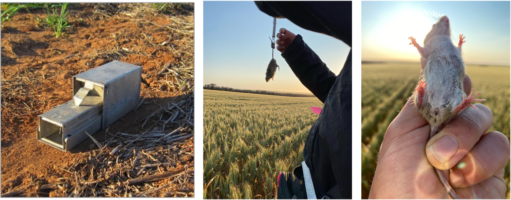

Live traps set in the field and captured mice.

**Rapid assessments** use two quick methods: *chew cards* (cards placed in paddocks that mice chew on) and *active burrow counts* (walking set transects and looking for burrows with fresh signs of mouse activity). For both, the result is presented as the proportion of cards chewed or transects with active burrows (averaged across sites for clean presentation).

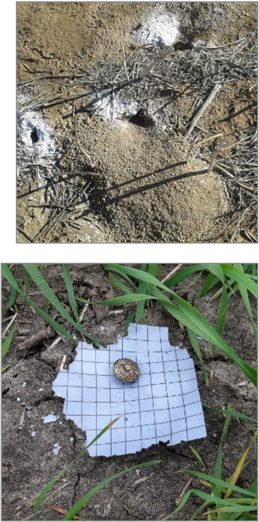

Active mouse burrows (top) and a chewed chew card (bottom).

## Survey locations

**Live-Trap Sites**

[interactive chart not shown]

**Rapid Assessment Sites**

[interactive chart not shown]

## Mouse Population Trends

### Live-Trap Results

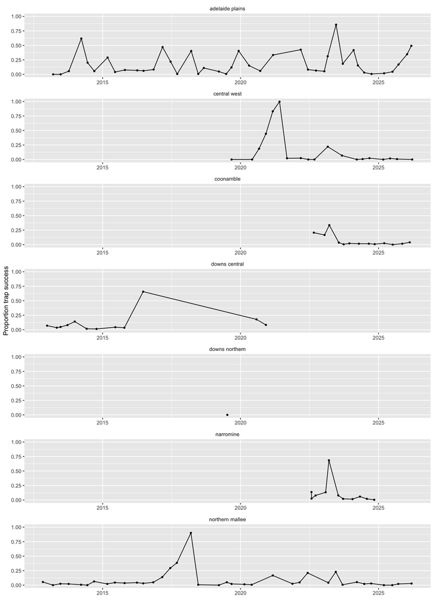

Figure 1: Average trap success per region across all monitoring years. Values are averaged across all sites and subsites within each region.

### Rapid Assessment Results

#### Active Burrow Counts

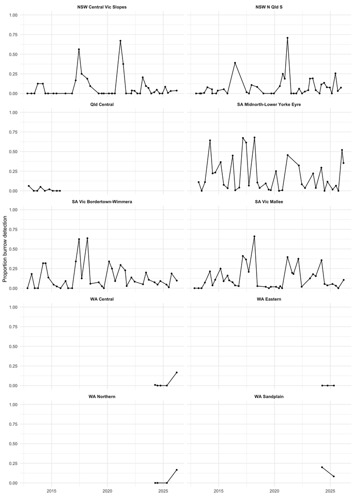

Figure 2: Average burrow detection rates per agroecological zone across all monitoring years. Values are averaged across all sites within each zone.

#### Chew Cards

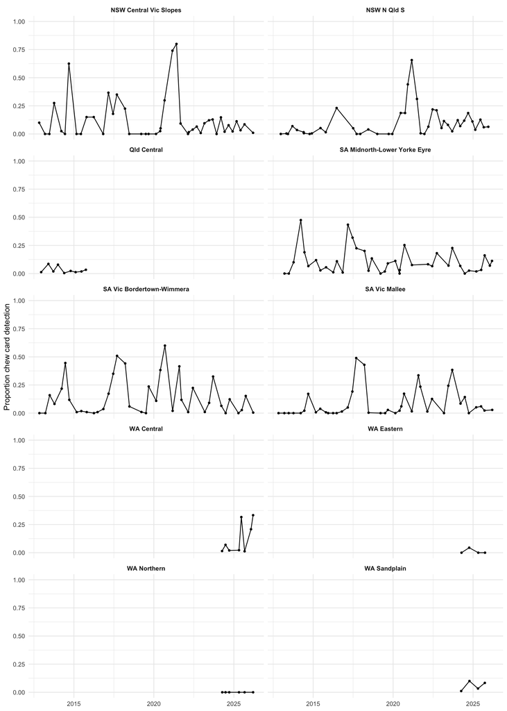

Figure 3: Average chew card detection rates per agroecological zone across all monitoring years. Values are averaged across all sites within each zone.

## Regional Summary

Table 1: Regional summary for recent seasons. Colour gradients: white = no/low activity, yellow = moderate, red = high activity.

| Season | Agroecological zone | Trap success (%) | Burrow detection (%) | Chew card detection (%) | Overall activity |
| --- | --- | --- | --- | --- | --- |
| Summer-2026 | NSW N Qld S | 3.9 | 8.2 | 5.5 | Moderate |
|  | SA Midnorth-Lower Yorke Eyre | 34.7 | 52.1 | 7.0 | High |
|  | WA Central | — | — | 20.8 | Moderate |
| Autumn-2026 | NSW Central Vic Slopes | 0.0 | 2.6 | 1.2 | Low |
|  | SA Midnorth-Lower Yorke Eyre | 49.2 | 41.1 | 18.7 | High |
|  | SA Vic Mallee | 2.8 | 8.3 | 2.1 | Moderate |
|  | SA Vic Bordertown-Wimmera | — | 7.7 | 0.8 | Moderate |
|  | WA Central | — | 16.7 | 33.3 | High |
|  | WA Northern | — | 16.7 | 0.0 | Moderate |

### Regional Summary Map

- **Trap success (T)**: The average proportion of live traps that caught a mouse, calculated across all sites and trapping sessions within each region for that season. For example, T: 5.2% means that on average 5.2% of traps set in that region caught a mouse.
- **Burrow detection (B)**: The average proportion of walked transects that had active mouse burrows, averaged across all sites within the region for that season.
- **Chew card detection (C)**: The average proportion of deployed chew cards that showed signs of mouse gnawing, averaged across all sites within the region for that season.
- **Activity level**: Classified based on the highest value among the three metrics — Low (below 5%), Moderate (5–25%), or High (above 25%).

[figure not shown]

Figure 4: Geographic overview of regional mouse activity. Point colour indicates overall activity level; labels show trap success (T), burrow detection (B), and chew card detection (C) where available.